[figure not shown]

*by Bart Smeets – bartsmeets86@gmail.com*

*simmer* is under heavy development and its internals and syntax can still change extensively over the coming time

*simmer* is a discrete event package for the R language. It is developed with my own specific requirements for simulating day-to-day hospital proceses and thus might not be suited for everyone. It is designed to be as simple to use as possible and tries to be compatible with the chaining/piping workflow introduced by the magrittr package.

## Installation

The installation requires the devtools package to be installed.

```r
devtools::install_github("Bart6114/simmer")
```

Please note that the package contains some C++ code and you thus need a development environment to build the package (e.g. [Rtools](http://cran.r-project.org/bin/windows/Rtools/) for Windows). If you don’t want to build the package yourself and you’re on Windows you could try a pre-built binary package here.

## Using simmer

First load the package.

```r
library(simmer)
```

Set-up a simple trajectory. Let’s say we want to simulate a ambulatory consultation where a patient is first seen by a nurse for an intake, next by a doctor for the consultation and finally by administrative staff to schedule a follow-up appointment.

```r
t0<-
  create_trajectory("my trajectory") %>%
  ## add an intake event
  add_seize_event("nurse",1.0) %>%
  add_timeout_event(15) %>%
  add_release_event("nurse",1.0) %>%
  ## add a consultation event
  add_seize_event("doctor",1.0) %>%
  add_timeout_event(20) %>%
  add_release_event("doctor",1.0) %>%
  ## add a planning event
  add_seize_event("administration",1.0) %>%
  add_timeout_event(5) %>%
  add_release_event("administration",1.0)
```

The time-out duration is evaluated as an R command if it is entered as a character value. This means that this does not have to be a static value and the concept of probability can be introduced. The following trajectory shows this.

```r
t1<-
  create_trajectory("my trajectory") %>%
  ## add an intake event
  add_seize_event("nurse",1.0) %>%
  add_timeout_event("rnorm(1,15)") %>%
  add_release_event("nurse",1.0) %>%
  ## add a consultation event
  add_seize_event("doctor",1.0) %>%
  add_timeout_event("rnorm(1,20)") %>%
  add_release_event("doctor",1.0) %>%
  ## add a planning event
  add_seize_event("administration",1.0) %>%
  add_timeout_event("rnorm(1,5)") %>%
  add_release_event("administration",1.0)
```

In the above trajectory the `duration` is drawn from a normal distribution with a given mean.

```r
sim<-
  create_simulator("SuperDuperSim", n = 100, until = 80) %>%
  add_resource("nurse", 1) %>%
  add_resource("doctor", 2) %>%
  add_resource("administration", 1)
```

The simulator object is extended by adding 10 entities - with trajectory `t1` - wich are activated with an interval of about 10 minutes.

```r
sim<-
  sim %>%
  add_entities_with_interval(trajectory = t1, n = 10, name_prefix = "patient", interval =  "rnorm(1, 10, 2)")
```

Entities can also be added on an individual basis. In the below example 1 extra individual entity is added which will be activated at time 100.

```r
sim<-
  sim %>%
  add_entity(trajectory = t1, name = "separate_patient" , activation_time =  100)
```

The simulation is now ready for a test run; just let it `simmer` for a bit.

```r
sim <-
  sim %>%
  simmer()
```

### Optional events

The *skip event* introduces the possibility of introducing probability in whether or not to include a step in a trajectory. The following example shows how a trajectory can be build with a 50-50 chance for the entitity to undergo the second *time-out event*.

```r
t2<-
  create_trajectory("trajectory with a skip event") %>%
  ## add a skip event - (50 - 50 chance that the next event is skipped)
  add_skip_event(number_to_skip = "sample(c(0,1),1)") %>%
  add_timeout_event(15) %>%
  add_timeout_event(5)
```

The `add_skip_event` command can be used to skip *n* number of events after the *skip event*. The *n* number of events to skip is specified using the `number_to_skip` parameter. It is import to enclose an command to be evaluated for each entity in quotes.

### Resource utilization

After you’ve left it simmering for a bit (pun intended), we can have a look at the overall resource utilization. The top and bottom of the error bars show respectively the 25th and 75th percentile of the utilization across all the replications. The top of the bar shows the median utilization.

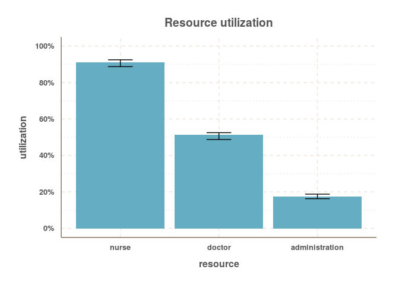

```r
plot_resource_utilization(sim, c("nurse", "doctor","administration"))
```

It is also possible to have a look at a specific resource and its activity during the simulation.

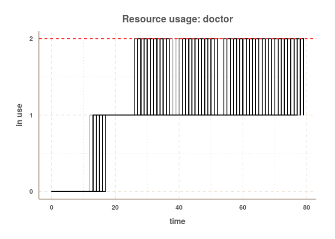

```r
plot_resource_usage(sim, "doctor")
```

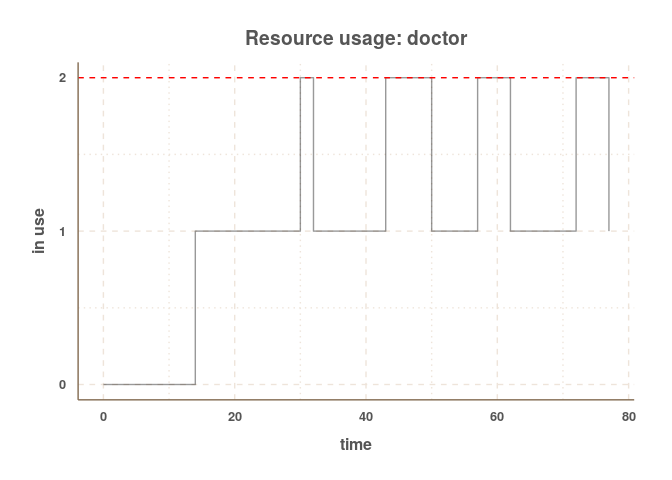

```r
plot_resource_usage(sim, "doctor", 6)
```

One can also query the raw resource monitor data.

```r
head(
  get_resource_monitor_values(sim, "nurse")
  )
```

```
##   time value resource replication
## 1    0     0    nurse           1
## 2    0     1    nurse           1
## 3   14     0    nurse           1
## 4   14     1    nurse           1
## 5   29     0    nurse           1
## 6   29     1    nurse           1
```

### Flow time

Next we can have a look at the evolution of the entities’ flow time during the simulation. In the below plot, each individual line represents a replication. A smoothline is drawn over them. All entities that didn’t finish their entire trajectory are excluded from the plot.

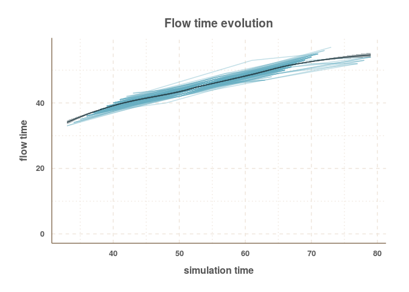

```r
plot_evolution_entity_times(sim, type = "flow_time")
```

Similarly one can have a look at the evolution of the activity times with `type = "activity_time"` and waiting times with `type = "waiting_time"`.

```r
head(
  get_entity_monitor_values(sim, aggregated = TRUE)
  )
```

```
##   replication entity_id start_time end_time finished activity_time
## 1           1         0          0       37        1            37
## 2           1         1          8       54        1            40
## 3           1         2         16       67        1            38
## 4           2         0          0       36        1            36
## 5           2         1          8       52        1            38
## 6           2         2         16       66        1            37
##   flow_time waiting_time
## 1        37            0
## 2        46            6
## 3        51           13
## 4        36            0
## 5        44            6
## 6        50           13
```

```r
head(
  get_entity_monitor_values(sim, aggregated = T)
  )
```

```
##   replication entity_id start_time end_time finished activity_time
## 1           1         0          0       37        1            37
## 2           1         1          8       54        1            40
## 3           1         2         16       67        1            38
## 4           2         0          0       36        1            36
## 5           2         1          8       52        1            38
## 6           2         2         16       66        1            37
##   flow_time waiting_time
## 1        37            0
## 2        46            6
## 3        51           13
## 4        36            0
## 5        44            6
## 6        50           13
```

**DOCUMENTATION TO BE CONTINUED**

## Roadmap

- Introduce *rewind event*
- Time-specific resource availability

## Contact

For bugs and/or issues: create a new issue on GitHub.

Other questions or comments: bartsmeets86@gmail.com